# PROSPER LOAN DATA ANALYSIS

Question:

- How does employment duration impact return?

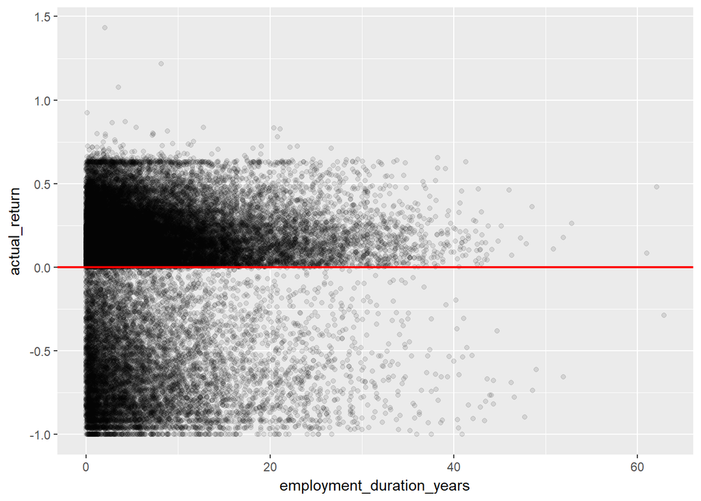

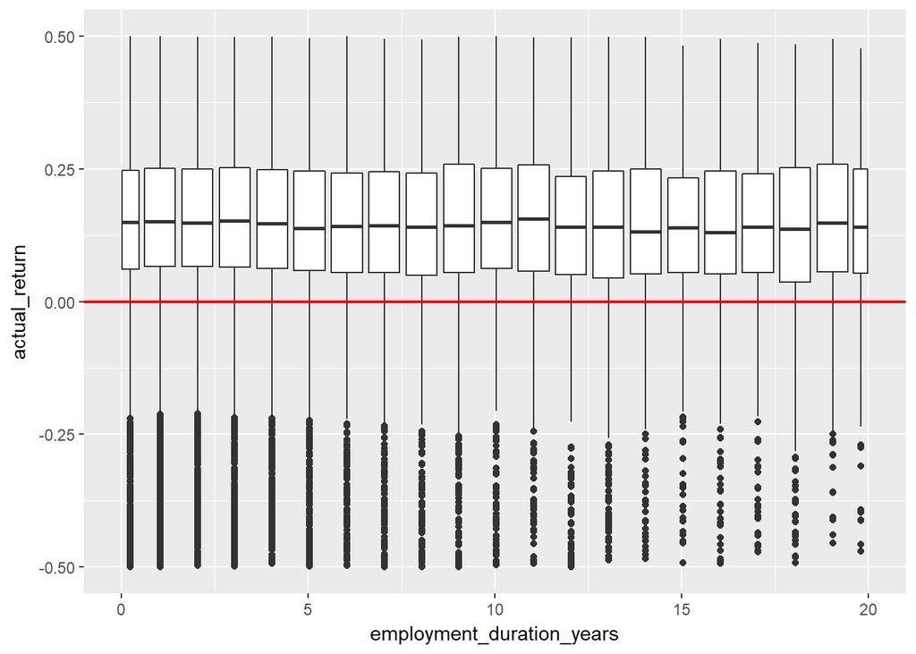

Question:

- How does stated annual income impact return?

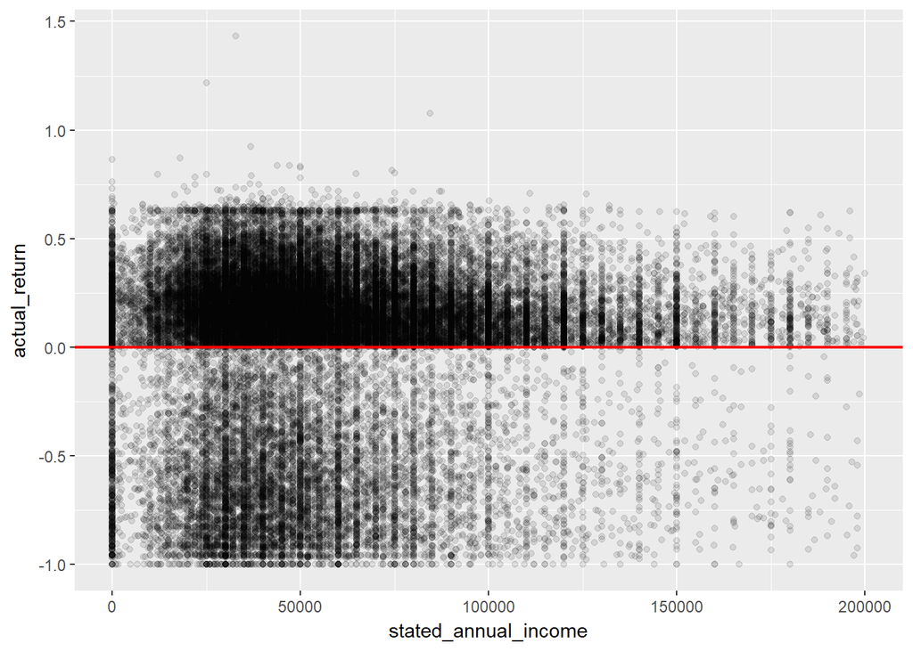

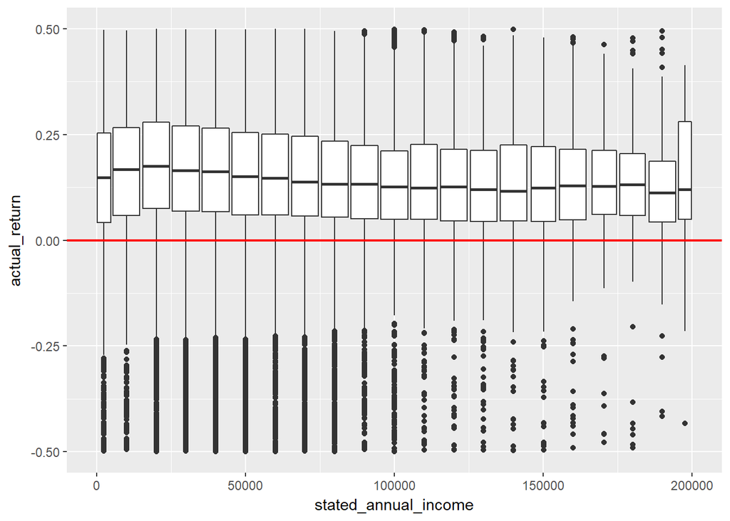

## Relationships between other variables

Question:

- What is the relationship between credit score and debt_income_ratio?

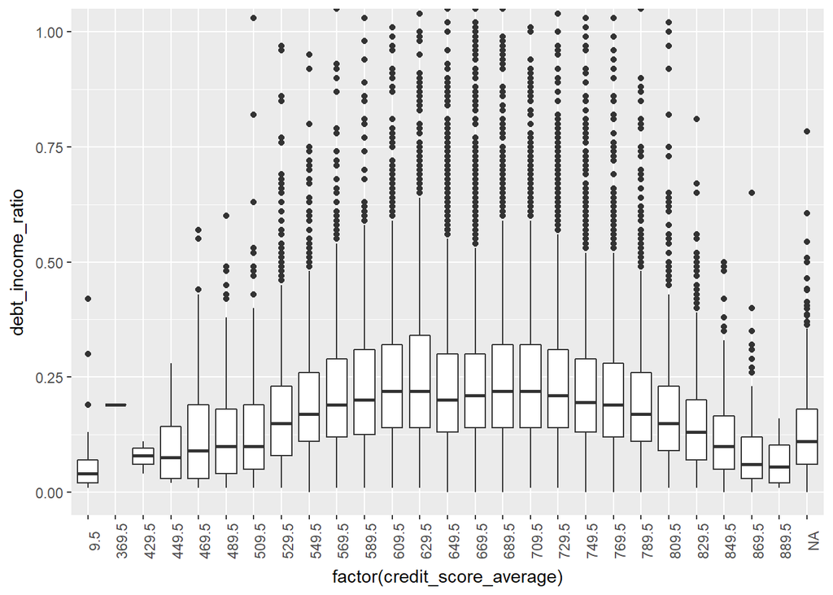

It looks like debt-to-income ratio is higher in the middle regions of the credit score range. I believe that debt to income ratio is one factor that influences credit score, so it makes sense that those with an excellent credit score would have a low debt to income ratio. I wonder if those with a score under 530 simply have a harder time getting a loan and therefore don’t have as much debt.

Question:

- Is a longer employment history correlated with a better credit score?

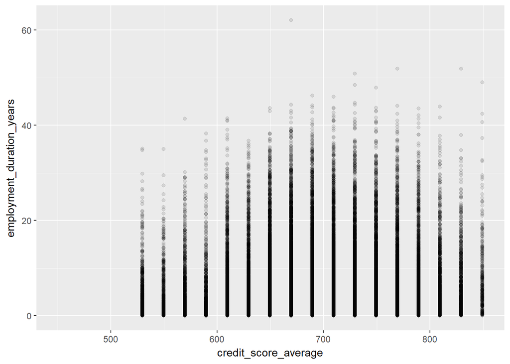

A longer employment duration does not appear to correlate with a better credit score.

# Bivariate Analysis

### Talk about some of the relationships you observed in this part of the investigation. How did the feature(s) of interest vary with other features in the dataset?

Loan term covaried with actual return. The return for one-year loans was mostly positive, but not much more than 0. Three-year loans brought in the highest return. Five-year loans were responsible for the most lost in return.

Credit score also varied with actual return. Credit scores centering right under 600 actually brought the highest level of return.

Otherwise, I really didn’t find any other patterns of covariation.

### What was the strongest relationship you found?

Credit score and actual return. Which makes sense, since the industry has spent years perfecting a single indicator that will tell the bank how trustworthy you are as an investment.

# Multivariate Plots Section

Question:

- Does loan term in years add any meaningful pattern to a graph of actual_return and credit_score_average?

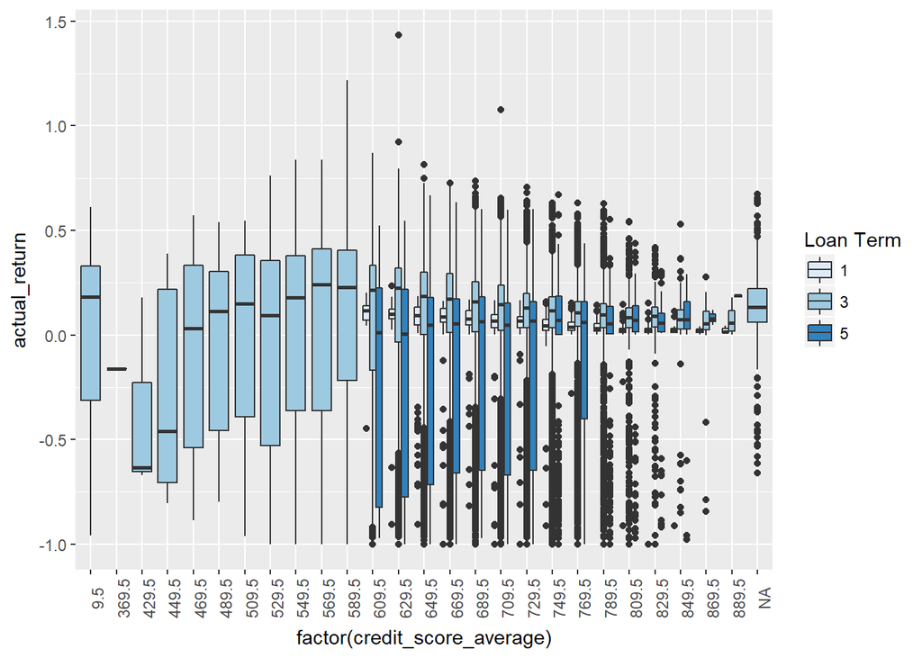

Question:

- Does employment_status help add a pattern to the relationship between credit score and return?

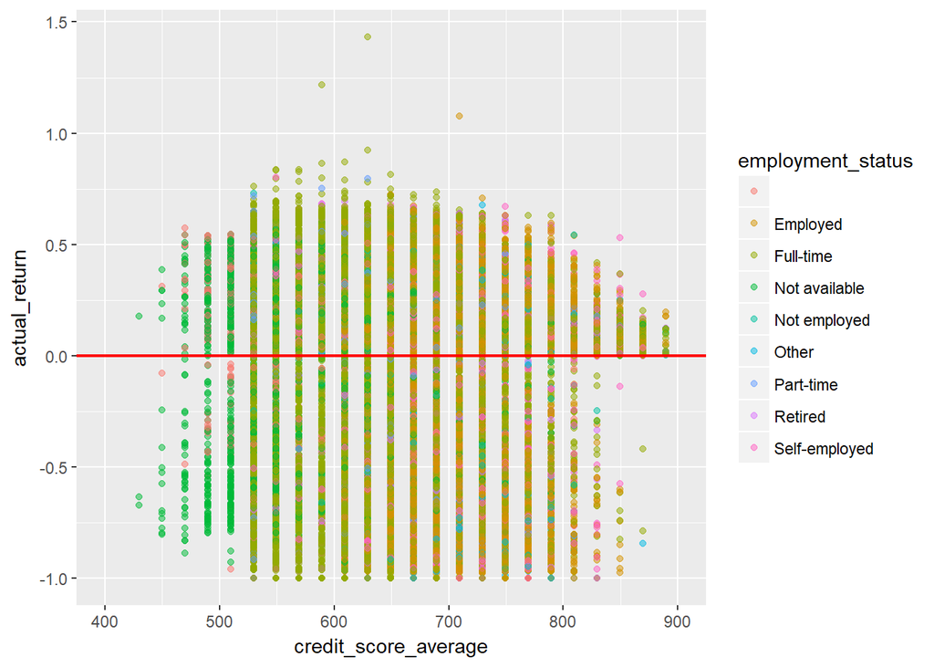

In this graph, we can see that the colors associated with ‘not available,’ ‘not employed,’ and ‘other’ occur more frequently in the lower credit scores, and that employment of some type or retirement occurs more frequently in the higher credit score ranges.

Question:

- Does debt-to-income ratio combined with employment status offer any new insight?

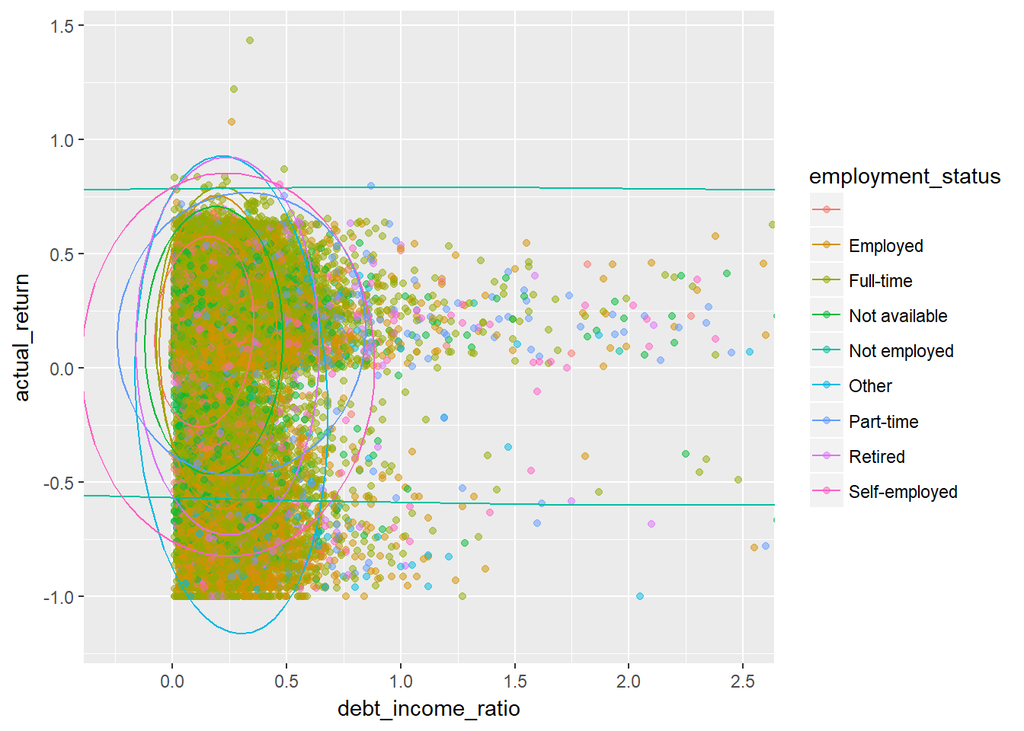

Adding employment status to this graph doesn’t show any new insights. Debt-to- income ratio combined with empoyment status does not seem to build a pattern.

# Multivariate Analysis

### Talk about some of the relationships you observed in this part of the investigation. Were there features that strengthened each other in terms of looking at your feature(s) of interest?

It looks like those with employment tend to have higher credit scores. But that was not particularly relevant to my exploration with actual return. I really struggled to uncover any interesting new insights with the multivariate analysis.

### Were there any interesting or surprising interactions between features?

Not really.

# Final Plots and Summary

### Plot One

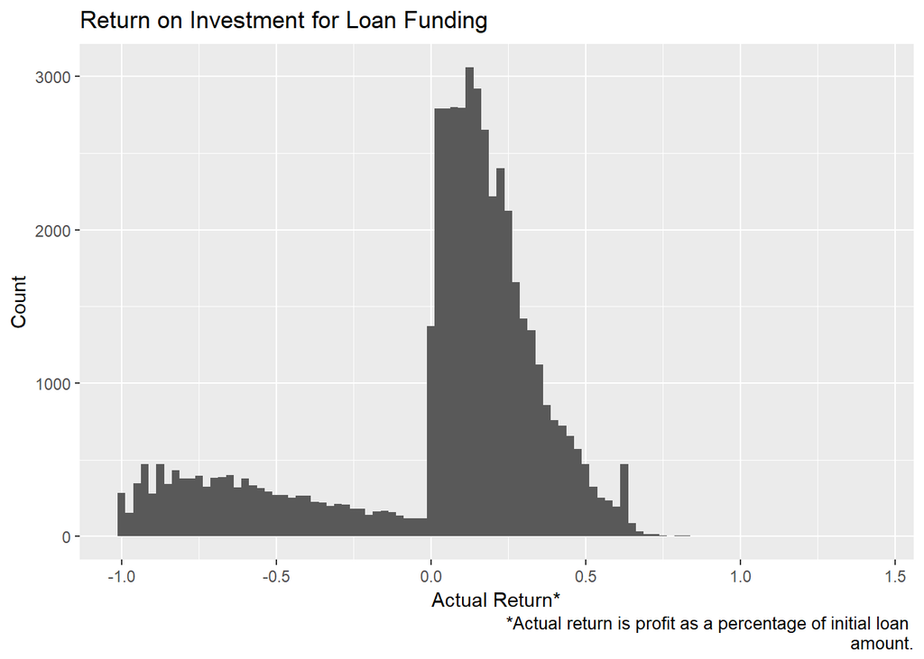

### Description One

This plot shows that most loans that have a positive return on investment. The average return for a funded loan is 2.8 percent.

```
##   mean_return_percent median_return_percent
## 1             2.78961              12.62516
```

### Plot Two

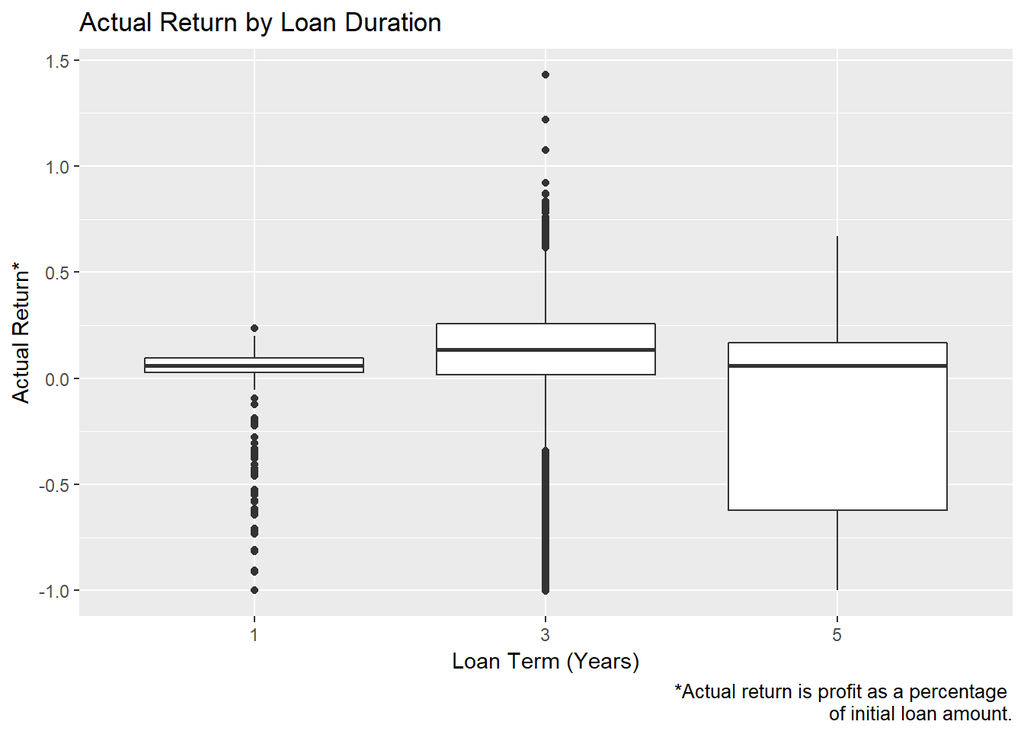

### Description Two

Prosper gives out loans that are one, three, or five years in duration. Almost 90 percent of loans are provided with a three year term. The median return for these loans is 13.6 percent. However, the average return is only 4 percent. Negative outliers are bringing the average lower than the median.

The median return for one-year loans is 5.9 percent, with average profit at 3.8 percent. And the median return for five-year loans is 5.8 percent, with average profit at negative 13.4 percent. As can be seen in the graph above, the second quartile for five-year loans falls into a negative return. The five-year loan category is not profitable for Prosper.

```
## # A tibble: 3 x 4
##   loan_term_years count return_mean_percent return_median_percent
##            <fctr> <int>               <dbl>                 <dbl>
## 1               1  1522            3.773682              5.931977
## 2               3 45034            4.015322             13.603792
## 3               5  3510          -13.363235              5.868050
```

### Plot Three

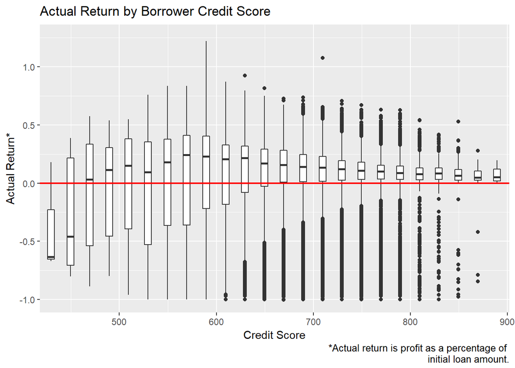

### Description Three

This graph shows that the median profit is above 0 for almost all credit score categories except those below 470. However, if we look at the mean profit, return becomes reliable above a credit score of 530.

```
## # A tibble: 27 x 4
##         bins count return_mean_percent return_median_percent
##       <fctr> <int>               <dbl>                 <dbl>
##  1  [-10,10]    74           2.3880312             18.044833
##  2 (350,370]     1         -16.3200000            -16.320000
##  3 (410,430]     3         -37.5565269            -63.421000
##  4 (430,450]    18         -28.7434131            -45.910333
##  5 (450,470]    69          -8.3218453              3.281759
##  6 (470,490]   185          -3.8029684             11.411500
##  7 (490,510]   351           0.9925621             15.048000
##  8 (510,530]  1288          -6.0840584              9.263300
##  9 (530,550]  1160           2.6534955             17.883179
## 10 (550,570]  1127           4.7879566             24.160000
## # ... with 17 more rows
```

# Reflection

What was challenging:

- I was surprised that I didn’t uncover a clear linear model or strong pattern between actual_return and the various factors I investigated. I was frustrated about that. Staying motivated on this project was difficult, because I didn’t feel like I uncovered any key insights.
- I didn’t get a chance to build a model because there were no linear relationships that emerged. Perhaps a more complex model could work, but I am currently not educated on those, so it was beyond the scope of my experience at this point in time.

What went well:

- I learned a lot about ggplot, using R studio, and how to approach the EDA process. One example of a process technique that I learned is to do a thorough exploration about variation (i.e. univariate analysis) and then move on to explore covariation (bivariate and mutlivariate analysis).
- I enjoyed the creativity and curiosity that the EDA process requires. I was able to practice using a wide range of graph types in ggplot.
- I am excited to take this skillset to analyzing other datasets.

Further areas for investigation:

- How does early payoff impact actual return? That is, if a borrower pays their loan off early, I anticipate that actual return would be lower.
- Analyze the difference between estimated return and actual return. Focus on areas where the bank anticipated profit but lost money. Is there a factor that their predictions should also take into account? Or is that just part of the risk of the lending process (e.g. the exploration would not uncover additional factors to create better predictive models of expected profit)?

# References

I consulted the following resources to help with this EDA project:

- R for Data Science by Hadley Wickham & Garrett Grolemund
- Online support forums for specific error messages